# A3: SPL Library Checkouts

### Introduction

In this report I have used a data set from the Seattle Public Library that has checkout information from the year 2017 to the year 2023. Using that data, I have analyzed the checkout trends for the library in that time period and seen the most popular books, checkout categories, and media. A lot of the emphasis of my report is on the year of 2020, when the world was in a state of pandemic and there was terror and uncertainty all around. The reason for me analyzing these trends and topics is because I feel libraries, especially public libraries, are a great representative of the society and what all is going on with it. It’s checkout trends reflect a lot about what is happening in the world. For example, we can take the year 2020 as an example. We can see the trends then represent something unusual, because of the amount of change that took place. Being a "special" year, it has gotten some special attention and mention in the report. Now, let’s find out these trends.

### Summary Information

Some of the observations made by analyzing the data for the year 2020 have been discussed here.

In 2020, the world discovered about the coronavirus and it’s ability to spread rapidly. Soon people started wearing gloves and masks to prevent exposure and physical contact became less prevalent. This trend made an impact on the checkouts at the Seattle Public Library. Digital materials were being used more than the traditional physical materials. This can be seen in the difference between the digtal checkouts versus the physical checkouts. The data shows there were 1271405 more digital materials checked out than the physical ones. The same number for the year 2017 is -2006816. The negative here shows that the number of digital copies checked out were less. Similarly, the two media types that were most commonly checked out in 2020 were EBOOK and AUDIOBOOK. Both of these are digital and this validates the trends seen above. Another thing I discovered from the data was the number of checkouts became less as the year progressed. The month 1 (January) had the maximum checkouts. This was a time until which the effect of covid were minimal. On the other hand, month 4 (April) has the least amount of checkouts. This was when the pandemic was at its peak. This analysis of the year 2020, made me curious about which item and which creator was the most checked out. The most checked out item was So You Want to Talk about Race (Unabridged) which is an AUDIOBOOK. An audiobook being the most checked out did not surprise me and further validated my analysis. On another hand, the most checked out creator was J. K. Rowling.

### The Dataset

The data set contains information on checkouts in the Seattle Public Library from 2017-2023.

- This data has been collected by the City of Seattle and has been published on their website, “Seattle Open Data”, which is open to the public and a user can find, analyze, and download data published by City departments.
- The data set contains twelve features:
  - Usage class (this is if the checked out item is physical or digital)
  - Checkout type
  - Material type (this defines the category of the item like - book, e-book, audiobook, etc.)
  - Checkout year
  - Checkout month
  - Number of checkouts
  - Title of the item
  - ISBN (it is the International Book Standard Number which is unique for every book)
  - Creator of the item
  - Subjects associated with it
  - Publisher
  - Publication year
- Among these features there are 816354 observations, each of one of which is associated with a single checked out item.
- This data set has been collected by the Seattle Public Library with the help of their check-out records that have been maintained since 2005.
- This data set is collected and made public by the City of Seattle for increasing life quality of their residents. By doing this, they hope to increase transparency, accountability, and comparability. They also hope to promote economic development and research.
- The questions of power or ethical questions associated with this data could be that of the privacy of the users of Seattle Public Library. Since this data is open to the public if the personal information of those checking out is present in the data set, it could raise huge privacy concerns. Luckily, the data doesn’t have any information whatsoever of those checking out. Additionally, it is also important that the consent of the users has been taken before collecting and making the data public.
- The possible limitations associated with this data set could be the time frame for which it was recorded and the size of the data set. The information in the data set is very limited with respect to the records on the Seattle Public Library and for an analysis that requires data of a longer time frame, it would be useless. Additionally, the size of the data set was too big in comparison to average data set which consumes more time of the user.

### First Trends Over Time Chart

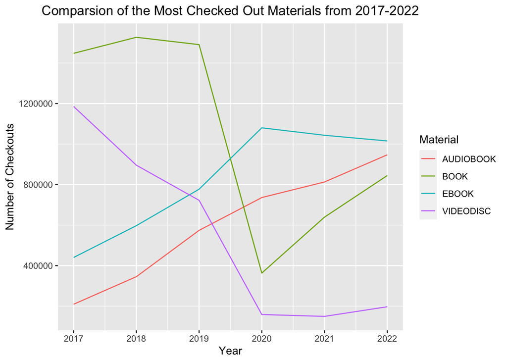

### Second Trends Over Time Chart

The second chart is a line chart that compares digital and physical media over the years. Here, we see the changing trends over the years. The more traditional physical media is being checked out way more than the newer digital media in the early part of the comparison. Somewhere in 2019, we see a shift in dominance from physical to digital media. This graph is important and the reason why I have included it in this report, because it shows two important trends in the Seattle Public Library check outs that correspond with the rest of the world. The first is, of course, the coronavirus and how people stopped checking out physical media for some time. But even before the years of the corona, we see a rise in digital media check outs. It also points to the fast pace at which technology was improving in the world and hence digital media was becoming more accessible and reliable. This chart is consistent with other trends we have noticed in the report.

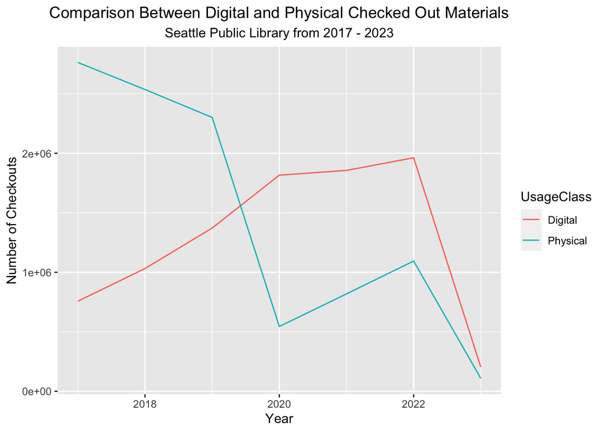

### Your Choice

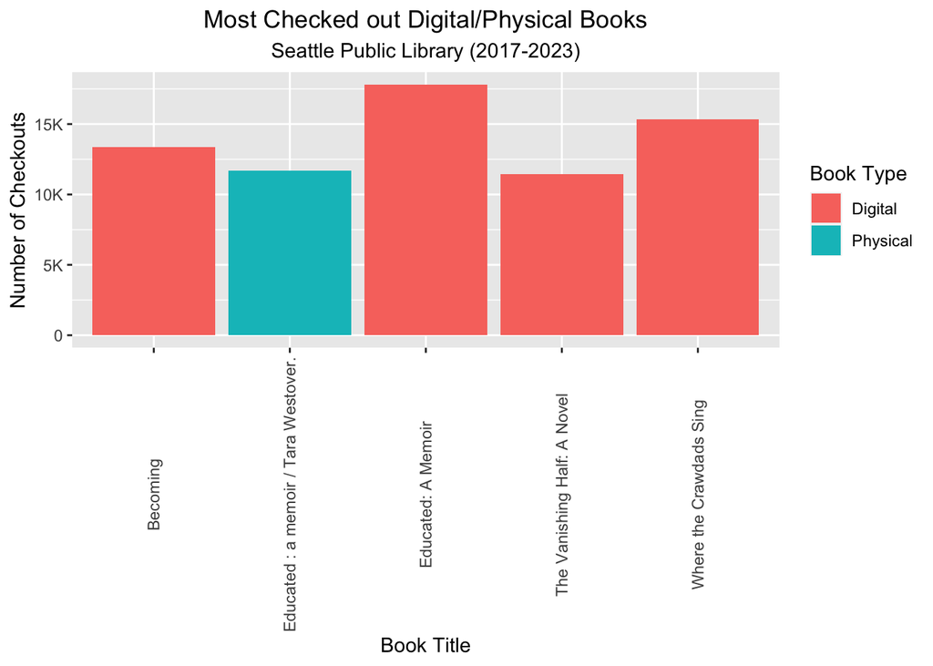